# LAtools

## Python Package for the Reduction of LA-ICPMS Data

## Getting Started

### Project Info

- Hosted on [**Github**](https://github.com/oscarbranson/latools).
- Registered on [**PyPi**](https://pypi.python.org/pypi/latools/), which means:

  ```
  pip install latools
  ```

- [**Documentation**](http://latools.readthedocs.io/en/latest/) on ReadTheDocs (compiled automatically on new version)
- [Build checked by **TravisCI**](https://travis-ci.org/oscarbranson/latools)

```python
# import package...
import latools as la
```

## Data Structure

```python
la.get_example_data('./Test_Data')
```

```python
import os

for d, dn, fn in os.walk('Test_Data/'):
    print(d)
    for f in sorted(fn):
        print('   {}'.format(f))
```

```
Test_Data/
   STD-1.csv
   STD-2.csv
   Sample-1.csv
   Sample-2.csv
   Sample-3.csv
```

## Data Format

```python
with open('Test_Data/STD-1.csv') as f:
    print(''.join(f.readlines()[:10]))
```

```
C:\ICPMH\1\DATA\15J29m00.B\STD-3.D
Intensity Vs Time,CPS
Acquired      : Oct 29 2015  03:06:01 pm using AcqMethod OB102915.m
Time [Sec],Mg24,Mg25,Al27,Ca43,Ca44,Mn55,Sr88,Ba137,Ba138
0.367,200.00,300.00,2200.14,366.67,17809.04,8652.16,0.00,0.00,12.50
0.725,466.67,200.00,2800.22,200.00,14506.00,7551.64,0.00,0.00,12.50
1.082,366.67,175.00,2000.11,466.67,13255.01,7151.47,100.00,25.00,0.00
1.439,466.67,75.00,1600.07,300.00,14405.92,8652.16,33.33,0.00,0.00
1.796,466.67,225.00,3000.25,200.00,14506.00,7551.64,100.00,0.00,0.00
2.153,200.00,175.00,2800.22,233.33,17258.49,8852.26,0.00,25.00,25.00
```

**Note**: Data formats are highly variable, but are all plain text. To accommodate this...

## Data Format Descriptions

- `.json` file.
- `RegEx` to identify metadata and column headings
- `numpy.genfromtext` arguments for reading data

```python
with open('/home/oscar/GitHub/latools/latools/resources/data_formats/UCD_dataformat.dict') as f:
    print(f.read())
```

```
{'genfromtext_args': {'delimiter': ',',
                      'skip_header': 4},
 'column_id': {'name_row': 3,
               'delimiter': ',',
               'timecolumn': 0,
               'pattern': '([A-z]{1,2}[0-9]{1,3})'},
 'meta_regex': {0: (['path'], '(.*)'),
                2: (['date', 'method'],
                    '([A-Z][a-z]+ [0-9]+ [0-9]{4}[ ]+[0-9:]+ [amp]+).* ([A-z0-9]+\.m)')},
 'unit': 'cps'
}
```

```
C:\ICPMH\1\DATA\15J29m00.B\STD-3.D
Intensity Vs Time,CPS
Acquired      : **Oct 29 2015  03:06:01 pm** using AcqMethod OB102915.m
Time [Sec],Mg24,Mg25,Al27,Ca43,Ca44,Mn55,Sr88,Ba137,Ba138
```

## The Data

```python
dat = la.analyse('Test_Data/')
```

```
Starting analysis using "UCD-AGILENT" configuration:
  5 Data Files Loaded: 2 standards, 3 samples
  Analytes: Mg24 Mg25 Al27 Ca43 Ca44 Mn55 Sr88 Ba137 Ba138
  Internal Standard: Ca43
```

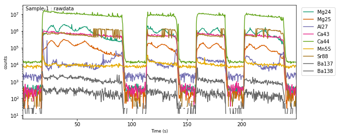

```python
fig, ax = dat.data['Sample-1'].tplot()
```

# *Interlude*

# Data Processing Workflow

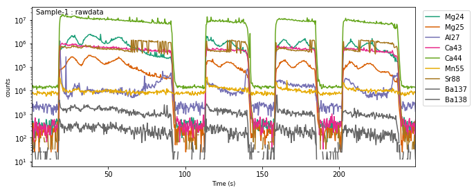

```python
fig, ax = dat.data['Sample-1'].tplot(focus_stage='rawdata')
```

## 1. Despiking

```python
dat.despike()
```

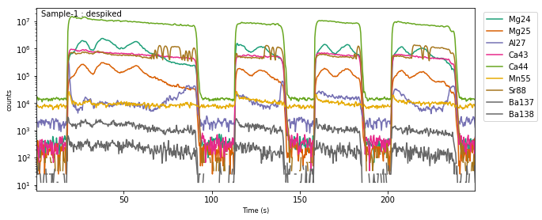

```python
fig, ax = dat.data['Sample-1'].tplot(focus_stage='despiked')
```

## 2. Laser on / Laser off separation

```python
dat.autorange()
```

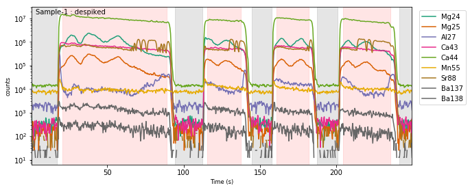

```python
fig, ax = dat.data['Sample-1'].tplot(ranges=True)
```

## 3. Background Correction

```python
dat.bkg_calc_weightedmean(weight_fwhm=250)
```

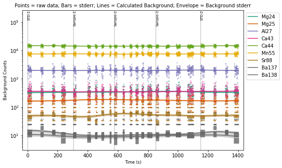

```python
fig, ax = dat.bkg_plot()
```

```python
dat.bkg_subtract()
```

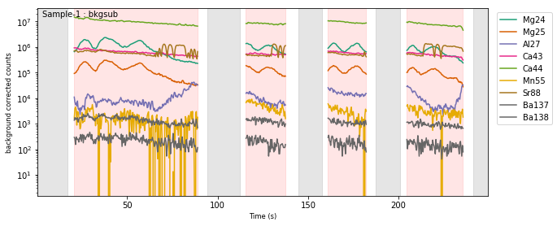

```python
fig, ax = dat.data['Sample-1'].tplot(ranges=True)
```

## 4. Internal Standardisation

```python
dat.ratio()
```

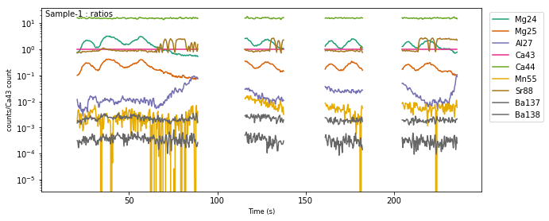

```python
fig, ax = dat.data['Sample-1'].tplot()
```

## 5. Calibration

```python
dat.calibrate(srms_used=['NIST610', 'NIST612', 'NIST614'])
```

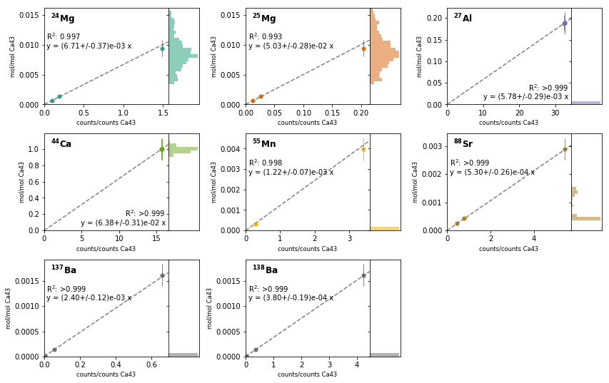

```python
fig, axs = dat.calibration_plot()
```

```
(1e-08, 0.1)
```

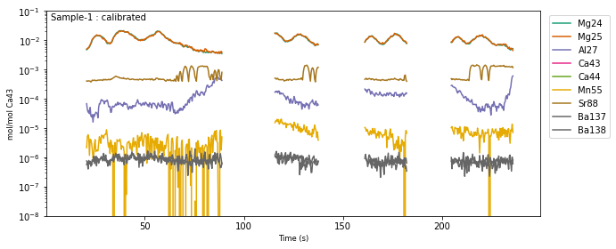

```python
fig, ax = dat.data['Sample-1'].tplot()
ax.set_ylim(1e-8, 1e-1)
```

## 6. Data Selection

```
(1e-08, 0.1)
```

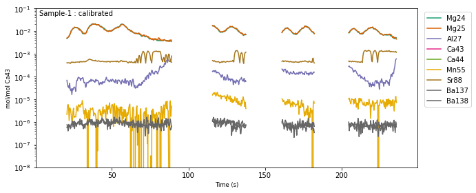

```python
fig, ax = dat.data['Sample-1'].tplot()
ax.set_ylim(1e-8, 1e-1)
```

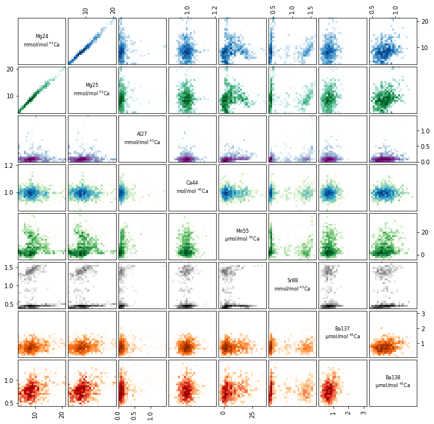

```python
fig, axs = dat.crossplot()
```

```python
dat.filter_threshold('Al27', 1e-4)
```

```python
dat.filter_on('Al27below', show_status=True)
```

```
Subset: All Samples

n  Filter Name          Mg24   Mg25   Al27   Ca43   Ca44   Mn55   Sr88   Ba137  Ba138
0  Al27_thresh_below    True   True   True   True   True   True   True   True   True
1  Al27_thresh_above    False  False  False  False  False  False  False  False  False
```

```
(1e-08, 0.1)
```

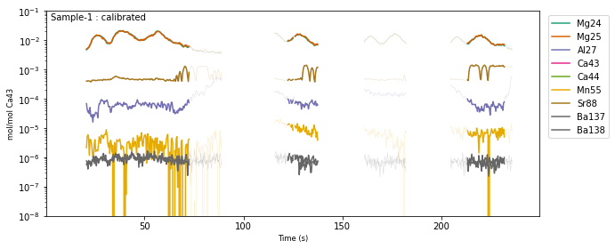

```python
fig, ax = dat.data['Sample-1'].tplot(filt=True)
ax.set_ylim(1e-8, 1e-1)
```

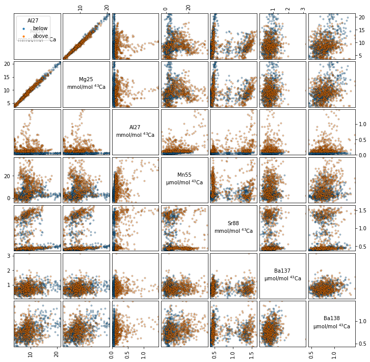

```python
fig, axs = dat.crossplot_filters('Al27')
```

## 7. Integration and Export

```python
dat.sample_stats()
```

```python
dat.getstats().dropna()
```

| statistic | sample | rep | Mg24 | Mg25 | Al27 | Ca44 | Mn55 | Sr88 | Ba137 | Ba138 |
| --- | --- | --- | --- | --- | --- | --- | --- | --- | --- | --- |
| mean | Sample-1 | 0 | 0.012484 | 0.012365 | 0.000058 | 0.984095 | 2.828208e-06 | 0.000506 | 9.038670e-07 | 8.810586e-07 |
|  |  | 1 | 0.011062 | 0.011455 | 0.000072 | 0.990677 | 9.207082e-06 | 0.000741 | 7.352279e-07 | 8.992930e-07 |
|  |  | 3 | 0.009767 | 0.009970 | 0.000059 | 0.987138 | 6.554444e-06 | 0.001167 | 6.828582e-07 | 7.174639e-07 |
|  | Sample-2 | 0 | 0.010596 | 0.010989 | 0.000085 | 0.999629 | 1.336641e-05 | 0.000427 | 6.580149e-07 | 7.860923e-07 |
|  |  | 1 | 0.008824 | 0.009141 | 0.000079 | 0.987442 | 1.294373e-05 | 0.000644 | 7.403601e-07 | 7.660156e-07 |
|  |  | 2 | 0.008379 | 0.008984 | 0.000094 | 1.002031 | 1.428687e-05 | 0.000493 | 7.096428e-07 | 8.305913e-07 |
|  |  | 3 | 0.007151 | 0.007452 | 0.000091 | 0.986143 | 1.826227e-05 | 0.000445 | 7.349530e-07 | 7.296629e-07 |
|  | Sample-3 | 0 | 0.008512 | 0.008751 | 0.000051 | 0.993711 | 9.917510e-07 | 0.000780 | 6.905797e-07 | 6.961825e-07 |
|  |  | 1 | 0.006836 | 0.007049 | 0.000048 | 0.999234 | 9.296239e-07 | 0.000804 | 6.570404e-07 | 6.791525e-07 |
|  |  | 2 | 0.006457 | 0.006577 | 0.000063 | 1.010412 | 1.487790e-06 | 0.000689 | 6.938047e-07 | 6.936474e-07 |
| std | Sample-1 | 0 | 0.004595 | 0.004338 | 0.000017 | 0.034003 | 2.028179e-06 | 0.000161 | 2.663841e-07 | 1.707551e-07 |
|  |  | 1 | 0.003014 | 0.003078 | 0.000013 | 0.043501 | 2.692357e-06 | 0.000349 | 2.494729e-07 | 1.867856e-07 |
|  |  | 3 | 0.002717 | 0.002747 | 0.000015 | 0.034204 | 2.026485e-06 | 0.000306 | 2.598313e-07 | 1.098980e-07 |
|  | Sample-2 | 0 | 0.001705 | 0.002015 | 0.000006 | 0.039736 | 1.404906e-06 | 0.000006 | 4.372299e-08 | 1.704213e-08 |
|  |  | 1 | 0.001210 | 0.001243 | 0.000013 | 0.026743 | 4.595181e-06 | 0.000393 | 3.280302e-07 | 1.262203e-07 |
|  |  | 2 | 0.000388 | 0.000528 | 0.000004 | 0.008025 | 3.471816e-06 | 0.000087 | 1.724928e-07 | 1.261159e-07 |
|  |  | 3 | 0.001002 | 0.001027 | 0.000007 | 0.034064 | 3.019104e-06 | 0.000020 | 3.260338e-07 | 1.020546e-07 |
|  | Sample-3 | 0 | 0.001677 | 0.001792 | 0.000036 | 0.034071 | 1.573408e-06 | 0.000461 | 2.802433e-07 | 1.429985e-07 |
|  |  | 1 | 0.001552 | 0.001591 | 0.000017 | 0.034290 | 1.822001e-06 | 0.000420 | 2.606903e-07 | 1.261460e-07 |
|  |  | 2 | 0.001566 | 0.001629 | 0.000018 | 0.042028 | 2.008081e-06 | 0.000386 | 2.540951e-07 | 1.200963e-07 |

## Workflow Synopsis

1. 'Despiking'
2. 'Laser On'/'Laser Off' Separation
3. Background ('baseline') correction
4. Internal Standardisation
5. Calibration
6. Data Selection
7. Integration and Export

# Building a UI

## Constraints

1. Build off existing code.
2. Cross-Platform
3. Open Source
4. Manual
5. Must be maintainable *by me*.

## Prejudices

1. GitHub is Great
2. Python is Perfect

## Examples I like

- Dioptas - Qt-based UI for X-Ray Diffraction Data Processing. Built using [pyqt](https://en.wikipedia.org/wiki/PyQt), so native Python!
- [TensorBoard](https://www.tensorflow.org/programmers_guide/summaries_and_tensorboard) - Browser-based UI for [TensorFlow](https://www.tensorflow.org/) machine learning framework... although more of a 'viewer' than a UI.

# Questions

- Do you need a space to work?
- Favourite development tools we should use?
- Any other thoughts?

# Next Steps

### Back-End:

- Get to grips with `latools`
- Assess suitability for connecting to UI.
- Highlight necessary changes.

### Middle:

- Survey GUI [options](https://wiki.python.org/moin/GuiProgramming) that play nicely with Python.
- Talk to Back-End folks, work out best option(s).

### Front-End:

- Design Ideas based on LA workflow

## Everyone: Present next week!